# Accidentalidad en Medellín

Valentina Serrato Henao

3/11/2020

Primero se carga el archivo previamente comprimiod a un .RData

```r
load(file.choose())
```

```r
#librerias necesarias
require(mixlm)
library(randomForest)
library(tree)
library(MASS)
```

Se divide el conjunto de datos en datos de entrenamiento(2015-2017) y datos de prueba (2018)

```r
## Seleccion del conjunto de entrenamiento y el conjunto de prueba
train<-accidentalidad[-which(accidentalidad$PERIODO=="2018"),]
test<-accidentalidad[which(accidentalidad$PERIODO=="2018"),]
```

### Arbol de regresión

Se plantea un modelo de arbol de regresión que permita predecir el *número de accidentes* usando como predictoras el dia, el mes, el nombre del día, la comúna, el riesgo de accidentalidad del barrio, y un conjunto de variables dummy que determina si es o no un día importante.

```r
library(rpart)
#Modelo de arbol de regresion para el número de accidentes
NumAccidentes_test<-test$`Numero de accidentes`
modelo1 <- rpart(`Numero de accidentes`~MES+DIA+DIA_NOMBRE+COMUNA+puente_festivo+puente_reyes+semana_santa+feria_flores+puente_semana_santa+festivo_entre_semana+no_festivo_importante+Riesgo, data=train, method = 'anova')
a1 <- predict(modelo1, test)

#MSE del conjunto de entrenamiento
msetrain<-mean((train$`Numero de accidentes`- predict(modelo1))^2)

#MSE del conjunto de prueba
msetest<- mean((NumAccidentes_test - a1)^2)

#variacion de los MSE
variacion_mse<-(msetest/msetrain)-1
msetest
```

```
## [1] 5.06317
```

```r
msetrain
```

```
## [1] 5.169926
```

```r
variacion_mse
```

```
## [1] -0.02064933
```

```r
cat("R Cuadrado \n")
```

```
## R Cuadrado
```

```r
R2 = cor(NumAccidentes_test, a1)^2
R2
```

```
## [1] 0.6667385
```

```r
cat("R Cuadrado ajustado \n")
```

```
## R Cuadrado ajustado
```

```r
1 - ((1 - R2) * (nrow(accidentalidad) - 1) / (nrow(accidentalidad) - ncol(accidentalidad) - 1))
```

```
## [1] 0.6666361
```

```r
summary(modelo1)
```

```
## Call:
## rpart(formula = `Numero de accidentes` ~ MES + DIA + DIA_NOMBRE +
##     COMUNA + puente_festivo + puente_reyes + semana_santa + feria_flores +
##     puente_semana_santa + festivo_entre_semana + no_festivo_importante +
##     Riesgo, data = train, method = "anova")
##   n= 44286
##
##           CP nsplit rel error    xerror        xstd
## 1 0.26796595      0 1.0000000 1.0000619 0.020810459
## 2 0.05749259      2 0.4640681 0.4643426 0.005980104
## 3 0.04482908      3 0.4065755 0.4068613 0.005619991
## 4 0.04246632      4 0.3617464 0.3588907 0.005388558
## 5 0.01138711      5 0.3192801 0.3195512 0.004554730
## 6 0.01120086      6 0.3078930 0.3113487 0.004504187
## 7 0.01000000      7 0.2966921 0.3029396 0.004261069
##
## Variable importance
##         Riesgo         COMUNA     DIA_NOMBRE puente_festivo
##             49             42              7              2
##
## Node number 1: 44286 observations,    complexity param=0.2679659
##   mean=3.812333, MSE=17.42522
##   left son=2 (41100 obs) right son=3 (3186 obs)
##   Primary splits:
##       COMUNA              splits as  LLLLLLLLLLLLLLLLLRLLLLLLLL, improve=0.237436400, (0 missing)
##       Riesgo              splits as  RLL, improve=0.168269100, (0 missing)
##       DIA_NOMBRE          splits as  LRRRRRR, improve=0.010630210, (0 missing)
##       puente_festivo      splits as  RL, improve=0.004807591, (0 missing)
##       puente_semana_santa splits as  RL, improve=0.001289786, (0 missing)
##
## Node number 2: 41100 observations,    complexity param=0.05749259
##   mean=3.24601, MSE=6.276924
##   left son=4 (21901 obs) right son=5 (19199 obs)
##   Primary splits:
##       COMUNA              splits as  LLRLLLRLLLLLLRRLL-RLLRLLLL, improve=0.171976000, (0 missing)
##       Riesgo              splits as  RLR, improve=0.141926900, (0 missing)
##       DIA_NOMBRE          splits as  LRRRRRR, improve=0.013309310, (0 missing)
##       puente_festivo      splits as  RL, improve=0.006929998, (0 missing)
##       puente_semana_santa splits as  RL, improve=0.002215938, (0 missing)
##   Surrogate splits:
```

[output cut: 68 more lines]

```
##   Surrogate splits:
##       puente_semana_santa splits as  RL, agree=0.923, adj=0.111, (0 split)
##       puente_reyes        splits as  RL, agree=0.920, adj=0.074, (0 split)
##
## Node number 22: 5119 observations
##   mean=4.154718, MSE=8.04717
##
## Node number 23: 8692 observations
##   mean=5.806259, MSE=8.088097
##
## Node number 30: 108 observations
##   mean=13.74074, MSE=76.82167
##
## Node number 31: 1144 observations
##   mean=23.09965, MSE=35.17538
```

Podemos ver que la variación de los MSE de prueba y entrenamiento es del 2%, también se ve que tenemos un $R^2=0.6667$ y $R^2_{adj}=0.6666$, por lo tanto el modelo sí explica en un 66.67% la variabilidad del número de accidentes.

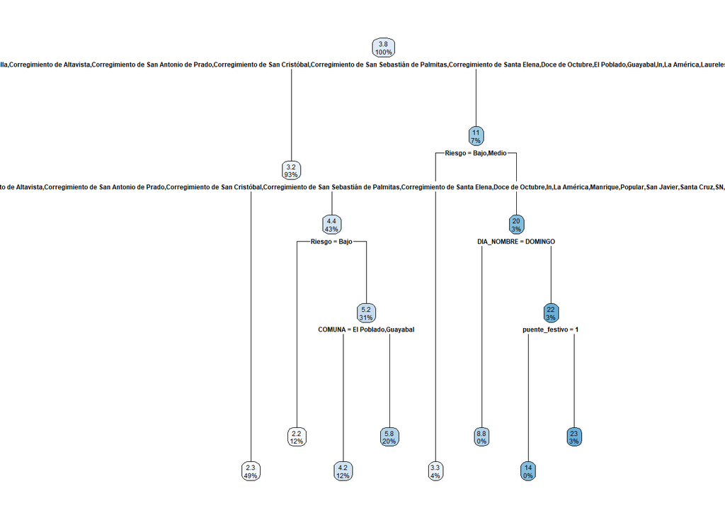

```r
library(rpart.plot)
rpart.plot(modelo1)
```

Se ajusta un modelo de regresión lineal múltiple para el número de *accidentes con solo daños*, usando como uno de los predictores el número de accidentes que resulta del modelo anterior, también el dia, el mes, el nombre del día, la comúna, el riesgo de accidentalidad del barrio, y un conjunto de variables dummy que determina si es o no un día importante.

```r
#Modelo de regresión lineal multiple para el número de accidentes con solo daños
NumAccidentesdaños_test<-test$`Accidente con solo daños`
modelo2<-lm(`Accidente con solo daños`~MES+DIA+DIA_NOMBRE+COMUNA+puente_festivo+puente_reyes+semana_santa+feria_flores+puente_semana_santa+festivo_entre_semana+no_festivo_importante+Riesgo+`Numero de accidentes`, data=train)
a2<-predict(modelo2, test)
#MSE del conjunto de entrenamiento
msetrain2<-mean((train$`Accidente con solo daños`- predict(modelo2))^2)
#MSE del conjunto de prueba
msetest2<- mean((NumAccidentesdaños_test - a2)^2)
#variacion de los MSE
variacion_mse2<-(msetest2/msetrain2)-1
msetest2
```

```
## [1] 1.014397
```

```r
msetrain2
```

```
## [1] 1.036596
```

```r
variacion_mse2
```

```
## [1] -0.02141495
```

```r
summary(modelo2)
```

```
##
## Call:
## lm(formula = `Accidente con solo daños` ~ MES + DIA + DIA_NOMBRE +
##     COMUNA + puente_festivo + puente_reyes + semana_santa + feria_flores +
##     puente_semana_santa + festivo_entre_semana + no_festivo_importante +
##     Riesgo + `Numero de accidentes`, data = train)
##
## Residuals:
##     Min      1Q  Median      3Q     Max
## -7.2981 -0.5539 -0.0228  0.6017  9.6401
##
## Coefficients:
##                          Estimate Std. Error t value Pr(>|t|)
## (Intercept)            -0.4291843  0.0685458  -6.261 3.85e-10 ***
## MES                     0.0068145  0.0014445   4.718 2.39e-06 ***
## DIA                     0.0000341  0.0005579   0.061 0.951255
## DIA_NOMBRE1            -0.1510402  0.0124921 -12.091  < 2e-16 ***
## DIA_NOMBRE2            -0.0121809  0.0120160  -1.014 0.310722
## DIA_NOMBRE3            -0.0014694  0.0119842  -0.123 0.902414
## DIA_NOMBRE4             0.0558886  0.0119366   4.682 2.85e-06 ***
## DIA_NOMBRE5             0.0118315  0.0119346   0.991 0.321516
## DIA_NOMBRE6             0.0135517  0.0120130   1.128 0.259290
## COMUNA1                 0.2995826  0.2166520   1.383 0.166738
## COMUNA2                -0.2885437  0.5662627  -0.510 0.610364
## COMUNA3                -0.2774553  0.0407198  -6.814 9.63e-12 ***
## COMUNA4                -0.0127332  0.2641004  -0.048 0.961546
## COMUNA5                 0.1287637  0.0393712   3.271 0.001074 **
## COMUNA6                -0.0331051  0.0408263  -0.811 0.417441
## COMUNA7                -0.1586241  0.0396060  -4.005 6.21e-05 ***
## COMUNA8                -0.0720027  0.0642390  -1.121 0.262355
## COMUNA9                 0.1449582  0.0503669   2.878 0.004003 **
## COMUNA10                0.0077416  0.0458307   0.169 0.865862
## COMUNA11                0.4103700  0.3282882   1.250 0.211295
## COMUNA12               -0.0124876  0.0543005  -0.230 0.818114
## COMUNA13               -0.4941556  0.0436854 -11.312  < 2e-16 ***
## COMUNA14                0.7212569  0.0394452  18.285  < 2e-16 ***
## COMUNA15                0.1453384  0.0403405   3.603 0.000315 ***
## COMUNA16                0.1684136  0.1025856   1.642 0.100662
## COMUNA17                0.1436803  0.0410604   3.499 0.000467 ***
## COMUNA18                0.5280426  0.0416784  12.669  < 2e-16 ***
```

[output cut: 9 more lines]

```
## semana_santa1           0.0069777  0.0211452   0.330 0.741408
## feria_flores1           0.0014472  0.0147683   0.098 0.921939
## puente_semana_santa1   -0.0402875  0.0341871  -1.178 0.238627
## festivo_entre_semana1   0.1214204  0.0324081   3.747 0.000179 ***
## no_festivo_importante1 -0.0336913  0.0234840  -1.435 0.151395
## Riesgo1                 0.0435822  0.0105259   4.140 3.47e-05 ***
## Riesgo2                 0.0627567  0.0086473   7.257 4.01e-13 ***
## `Numero de accidentes`  0.5208512  0.0015114 344.611  < 2e-16 ***
## ---
## Signif. codes:  0 '***' 0.001 '**' 0.01 '*' 0.05 '.' 0.1 ' ' 1
##
## s: 1.019 on 44242 degrees of freedom
## Multiple R-squared: 0.8354,
## Adjusted R-squared: 0.8352
## F-statistic:  5222 on 43 and 44242 DF,  p-value: < 2.2e-16
```

Podemos ver que la variación de los MSE de prueba y entrenamiento es del 2% un valor bajo, también se ve que tenemos un $R^2=0.8354$ y $R^2_{adj}=0.8352$, al ser valores casi iguales entonces se puede concluir que el modelo sí explica en un 84% la variabilidad del número de accidentes con solo daños.

Se utilizará el método forward para depurar un poco el modelo y encontrar uno más parsimonioso.

```r
forward(modelo2)
```

```
## Forward selection, alpha-to-enter: 0.2
##
## Full model: `Accidente con solo daños` ~ MES + DIA + DIA_NOMBRE + COMUNA +
##     puente_festivo + puente_reyes + semana_santa + feria_flores +
##     puente_semana_santa + festivo_entre_semana + no_festivo_importante +
##     Riesgo + `Numero de accidentes`
## <environment: 0x000000004ff0e308>
```

```
##                         Step    RSS     AIC  R2pred         Cp    F value
## COMUNA                     1 190272 64611.4 0.31736 139137.962 8.2479e+02
## Riesgo                     1 226602 72304.0 0.31736 139137.962 5.1115e+03
## `Numero de accidentes`     1  51061  6307.9 0.31736 139137.962 1.9761e+05
## Riesgo1                    2 173755 60593.9 0.37655 123224.004 2.1036e+03
## `Numero de accidentes`1    2  46442  2158.7 0.37655 123224.004 1.3707e+05
## `Numero de accidentes`2    3  46181  1913.2 0.83425    278.020 1.2226e+05
## DIA_NOMBRE                 4  45959  1712.5 0.83500     76.717 3.5517e+01
## MES                        5  45937  1693.4 0.83507     57.696 2.1011e+01
## festivo_entre_semana       6  45923  1681.3 0.83512     45.592 1.4102e+01
## puente_festivo             7  45911  1671.8 0.83515     36.088 1.1505e+01
## no_festivo_importante      8  45909  1671.8 0.83515     36.050 2.0376e+00
##                            Pr(>F)
## COMUNA                  < 2.2e-16 ***
## Riesgo                  < 2.2e-16 ***
## `Numero de accidentes`  < 2.2e-16 ***
## Riesgo1                 < 2.2e-16 ***
## `Numero de accidentes`1 < 2.2e-16 ***
## `Numero de accidentes`2 < 2.2e-16 ***
## DIA_NOMBRE              < 2.2e-16 ***
## MES                      4.58e-06 ***
## festivo_entre_semana    0.0001734 ***
## puente_festivo          0.0006948 ***
## no_festivo_importante   0.1534551
## ---
## Signif. codes:  0 '***' 0.001 '**' 0.01 '*' 0.05 '.' 0.1 ' ' 1
```

```
##
## Call:
## lm(formula = `Accidente con solo daños` ~ COMUNA + Riesgo + `Numero de accidentes` +
##     DIA_NOMBRE + MES + festivo_entre_semana + puente_festivo +
##     no_festivo_importante, data = train)
##
## Coefficients:
##            (Intercept)                 COMUNA1                 COMUNA2
##              -0.477048                0.299758               -0.287300
##                COMUNA3                 COMUNA4                 COMUNA5
##              -0.277248               -0.013731                0.128882
##                COMUNA6                 COMUNA7                 COMUNA8
##              -0.032941               -0.158548               -0.071564
##                COMUNA9                COMUNA10                COMUNA11
##               0.144686                0.007632                0.406816
##               COMUNA12                COMUNA13                COMUNA14
##              -0.012209               -0.493864                0.721331
##               COMUNA15                COMUNA16                COMUNA17
##               0.145171                0.168236                0.143718
##               COMUNA18                COMUNA19                COMUNA20
##               0.528629                0.340588               -0.284452
##               COMUNA21                COMUNA22                COMUNA23
##              -0.299883               -0.388436               -0.161117
##               COMUNA24                COMUNA25                 Riesgo1
##              -0.191502               -0.248269                0.043755
##                Riesgo2  `Numero de accidentes`             DIA_NOMBRE1
##               0.062618                0.520786               -0.151468
##            DIA_NOMBRE2             DIA_NOMBRE3             DIA_NOMBRE4
##              -0.011016               -0.002536                0.055911
##            DIA_NOMBRE5             DIA_NOMBRE6                     MES
##               0.011813                0.013043                0.006547
##  festivo_entre_semana1         puente_festivo1  no_festivo_importante1
##               0.121798                0.029053               -0.033512
```

Se ajusta un modelo de regresión lineal múltiple para el número de *accidentes con heridos*, usando como uno de los predictores el número de accidentes que resulta del primer modelo, también el dia, el mes, el nombre del día, la comúna, el riesgo de accidentalidad del barrio, y un conjunto de variables dummy que determina si es o no un día importante.

```r
#Modelo de regresión lineal multiple para el número de accidentes con heridos
NumAccidentesheridos_test<-test$`Accidentes con Heridos`
modelo3<-lm(`Accidentes con Heridos`~MES+DIA+DIA_NOMBRE+COMUNA+puente_festivo+puente_reyes+semana_santa+feria_flores+puente_semana_santa+festivo_entre_semana+no_festivo_importante+Riesgo+`Numero de accidentes`, data=train)
a3<-predict(modelo3, test)
#MSE del conjunto de entrenamiento
msetrain3<-mean((train$`Accidentes con Heridos`- predict(modelo3))^2)
#MSE del conjunto de prueba
msetest3<- mean((NumAccidentesheridos_test - a3)^2)
#variacion de los MSE
variacion_mse3<-(msetrain3/msetest3)-1
msetest3
```

```
## [1] 1.004133
```

```r
msetrain3
```

```
## [1] 1.029467
```

```r
variacion_mse3
```

```
## [1] 0.02522995
```

```r
summary(modelo3)
```

```
##
## Call:
## lm(formula = `Accidentes con Heridos` ~ MES + DIA + DIA_NOMBRE +
##     COMUNA + puente_festivo + puente_reyes + semana_santa + feria_flores +
##     puente_semana_santa + festivo_entre_semana + no_festivo_importante +
##     Riesgo + `Numero de accidentes`, data = train)
##
## Residuals:
##     Min      1Q  Median      3Q     Max
## -9.4791 -0.6043  0.0232  0.5508  7.4496
##
## Coefficients:
##                          Estimate Std. Error t value Pr(>|t|)
## (Intercept)             0.4118924  0.0683097   6.030 1.65e-09 ***
## MES                    -0.0064576  0.0014395  -4.486 7.28e-06 ***
## DIA                    -0.0001534  0.0005560  -0.276 0.782548
## DIA_NOMBRE1             0.1413750  0.0124490  11.356  < 2e-16 ***
## DIA_NOMBRE2             0.0175322  0.0119746   1.464 0.143169
## DIA_NOMBRE3            -0.0019363  0.0119429  -0.162 0.871202
## DIA_NOMBRE4            -0.0547757  0.0118955  -4.605 4.14e-06 ***
## DIA_NOMBRE5            -0.0073285  0.0118935  -0.616 0.537781
## DIA_NOMBRE6            -0.0165969  0.0119716  -1.386 0.165645
## COMUNA1                -0.3814604  0.2159058  -1.767 0.077270 .
## COMUNA2                 0.3046012  0.5643123   0.540 0.589356
## COMUNA3                 0.2711304  0.0405795   6.681 2.39e-11 ***
## COMUNA4                -0.0451907  0.2631907  -0.172 0.863672
## COMUNA5                -0.1158523  0.0392356  -2.953 0.003151 **
## COMUNA6                 0.0404964  0.0406857   0.995 0.319572
## COMUNA7                 0.1657098  0.0394696   4.198 2.69e-05 ***
## COMUNA8                 0.0702066  0.0640178   1.097 0.272790
## COMUNA9                -0.1553568  0.0501934  -3.095 0.001968 **
## COMUNA10               -0.0062812  0.0456728  -0.138 0.890616
## COMUNA11               -0.3976333  0.3271574  -1.215 0.224213
## COMUNA12                0.0169490  0.0541134   0.313 0.754120
## COMUNA13                0.4971154  0.0435350  11.419  < 2e-16 ***
## COMUNA14               -0.7036044  0.0393094 -17.899  < 2e-16 ***
## COMUNA15               -0.1393602  0.0402016  -3.467 0.000528 ***
## COMUNA16               -0.1749994  0.1022323  -1.712 0.086944 .
## COMUNA17               -0.1339403  0.0409190  -3.273 0.001064 **
## COMUNA18               -0.5246591  0.0415348 -12.632  < 2e-16 ***
```

[output cut: 9 more lines]

```
## semana_santa1          -0.0042150  0.0210724  -0.200 0.841460
## feria_flores1           0.0091067  0.0147174   0.619 0.536071
## puente_semana_santa1    0.0338915  0.0340694   0.995 0.319849
## festivo_entre_semana1  -0.1233307  0.0322965  -3.819 0.000134 ***
## no_festivo_importante1  0.0326076  0.0234032   1.393 0.163536
## Riesgo1                -0.0477085  0.0104897  -4.548 5.43e-06 ***
## Riesgo2                -0.0634423  0.0086175  -7.362 1.84e-13 ***
## `Numero de accidentes`  0.4731846  0.0015062 314.156  < 2e-16 ***
## ---
## Signif. codes:  0 '***' 0.001 '**' 0.01 '*' 0.05 '.' 0.1 ' ' 1
##
## s: 1.015 on 44242 degrees of freedom
## Multiple R-squared: 0.7803,
## Adjusted R-squared:  0.78
## F-statistic:  3653 on 43 and 44242 DF,  p-value: < 2.2e-16
```

Podemos ver que la variación de los MSE de prueba y entrenamiento es del 2% un valor bajo, también se ve que tenemos un $R^2=0.7803$ y $R^2_{adj}=0.78$, al ser valores casi iguales entonces se puede concluir que el modelo sí explica en un 78% la variabilidad del número de accidentes con heridos.

Se utilizará el método forward para depurar un poco el modelo y encontrar uno más parsimonioso.

```r
forward(modelo3)
```

```
## Forward selection, alpha-to-enter: 0.2
##
## Full model: `Accidentes con Heridos` ~ MES + DIA + DIA_NOMBRE + COMUNA +
##     puente_festivo + puente_reyes + semana_santa + feria_flores +
##     puente_semana_santa + festivo_entre_semana + no_festivo_importante +
##     Riesgo + `Numero de accidentes`
## <environment: 0x000000004fed7728>
```

```
##                         Step    RSS     AIC  R2pred         Cp    F value
## COMUNA                     1 162802 57706.5 0.21473 113751.211 4.8572e+02
## Riesgo                     1 178953 61849.4 0.21473 113751.211 3.5281e+03
## `Numero de accidentes`     1  50664  5962.5 0.21473 113751.211 1.3706e+05
## Riesgo1                    2 148527 53646.3 0.28350  99902.062 2.1269e+03
## `Numero de accidentes`1    2  46116  1847.3 0.28350  99902.062 1.1199e+05
## `Numero de accidentes`2    3  45835  1580.3 0.77884    250.581 9.9157e+04
## DIA_NOMBRE                 4  45640  1403.2 0.77972     73.092 3.1554e+01
## MES                        5  45620  1386.1 0.77981     55.918 1.9165e+01
## festivo_entre_semana       6  45605  1373.5 0.77987     43.390 1.4526e+01
## puente_festivo             7  45595  1366.2 0.77991     36.093 9.2970e+00
## no_festivo_importante      8  45593  1366.3 0.77991     36.208 1.8856e+00
##                            Pr(>F)
## COMUNA                  < 2.2e-16 ***
## Riesgo                  < 2.2e-16 ***
## `Numero de accidentes`  < 2.2e-16 ***
## Riesgo1                 < 2.2e-16 ***
## `Numero de accidentes`1 < 2.2e-16 ***
## `Numero de accidentes`2 < 2.2e-16 ***
## DIA_NOMBRE              < 2.2e-16 ***
## MES                     1.202e-05 ***
## festivo_entre_semana    0.0001384 ***
## puente_festivo          0.0022966 **
## no_festivo_importante   0.1697115
## ---
## Signif. codes:  0 '***' 0.001 '**' 0.01 '*' 0.05 '.' 0.1 ' ' 1
```

```
##
## Call:
## lm(formula = `Accidentes con Heridos` ~ COMUNA + Riesgo + `Numero de accidentes` +
##     DIA_NOMBRE + MES + festivo_entre_semana + puente_festivo +
##     no_festivo_importante, data = train)
##
## Coefficients:
##            (Intercept)                 COMUNA1                 COMUNA2
##               0.467936               -0.380959                0.302680
##                COMUNA3                 COMUNA4                 COMUNA5
##               0.270976               -0.043790               -0.115997
##                COMUNA6                 COMUNA7                 COMUNA8
##               0.040295                0.165578                0.069749
##                COMUNA9                COMUNA10                COMUNA11
##              -0.155123               -0.006185               -0.393760
##               COMUNA12                COMUNA13                COMUNA14
##               0.016449                0.496827               -0.703766
##               COMUNA15                COMUNA16                COMUNA17
##              -0.139300               -0.174543               -0.134042
##               COMUNA18                COMUNA19                COMUNA20
##              -0.525142               -0.323943                0.286092
##               COMUNA21                COMUNA22                COMUNA23
##               0.306979                0.403345                0.163428
##               COMUNA24                COMUNA25                 Riesgo1
##               0.192018                0.261539               -0.047832
##                Riesgo2  `Numero de accidentes`             DIA_NOMBRE1
##              -0.063341                0.473226                0.141478
##            DIA_NOMBRE2             DIA_NOMBRE3             DIA_NOMBRE4
##               0.016781               -0.001003               -0.054600
##            DIA_NOMBRE5             DIA_NOMBRE6                     MES
##              -0.007091               -0.016414               -0.006230
##  festivo_entre_semana1         puente_festivo1  no_festivo_importante1
##              -0.123126               -0.026037                0.032126
```

Se ajusta un modelo de regresión lineal múltiple para el número de *accidentes con muertos*, usando como uno de los predictores el número de accidentes que resulta del primer modelo, también el dia, el mes, el nombre del día, la comúna, el riesgo de accidentalidad del barrio, y un conjunto de variables dummy que determina si es o no un día importante.

```r
#Modelo de regresión lineal multiple para el número de accidentes con muertos
NumAccidentesmuertos_test<-test$`Accidente de muertos`
modelo4<-lm(`Accidente de muertos`~MES+DIA+DIA_NOMBRE+COMUNA+puente_festivo+puente_reyes+semana_santa+feria_flores+puente_semana_santa+festivo_entre_semana+no_festivo_importante+Riesgo+`Numero de accidentes`, data=train)
a4<-predict(modelo4, test)
#MSE del conjunto de entrenamiento
msetrain4<-mean((train$`Accidente de muertos`- predict(modelo4))^2)
#MSE del conjunto de prueba
msetest4<- mean((NumAccidentesmuertos_test - a4)^2)
#variacion de los MSE
variacion_mse4<-(msetrain4/msetest4)-1
msetest4
```

```
## [1] 0.03690023
```

```r
msetrain4
```

```
## [1] 0.02219283
```

```r
variacion_mse4
```

```
## [1] -0.398572
```

```r
summary(modelo4)
```

```
##
## Call:
## lm(formula = `Accidente de muertos` ~ MES + DIA + DIA_NOMBRE +
##     COMUNA + puente_festivo + puente_reyes + semana_santa + feria_flores +
##     puente_semana_santa + festivo_entre_semana + no_festivo_importante +
##     Riesgo + `Numero de accidentes`, data = train)
##
## Residuals:
##      Min       1Q   Median       3Q      Max
## -0.29619 -0.02730 -0.01528 -0.00614  2.96689
##
## Coefficients:
##                          Estimate Std. Error t value Pr(>|t|)
## (Intercept)             1.729e-02  1.003e-02   1.724  0.08470 .
## MES                    -3.569e-04  2.114e-04  -1.689  0.09131 .
## DIA                     1.193e-04  8.163e-05   1.462  0.14375
## DIA_NOMBRE1             9.665e-03  1.828e-03   5.288 1.24e-07 ***
## DIA_NOMBRE2            -5.351e-03  1.758e-03  -3.044  0.00234 **
## DIA_NOMBRE3             3.406e-03  1.754e-03   1.942  0.05211 .
## DIA_NOMBRE4            -1.113e-03  1.747e-03  -0.637  0.52399
## DIA_NOMBRE5            -4.503e-03  1.746e-03  -2.579  0.00992 **
## DIA_NOMBRE6             3.045e-03  1.758e-03   1.732  0.08319 .
## COMUNA1                 8.188e-02  3.170e-02   2.583  0.00980 **
## COMUNA2                -1.606e-02  8.286e-02  -0.194  0.84633
## COMUNA3                 6.325e-03  5.958e-03   1.062  0.28843
## COMUNA4                 5.792e-02  3.864e-02   1.499  0.13389
## COMUNA5                -1.291e-02  5.761e-03  -2.241  0.02501 *
## COMUNA6                -7.391e-03  5.974e-03  -1.237  0.21597
## COMUNA7                -7.086e-03  5.795e-03  -1.223  0.22145
## COMUNA8                 1.796e-03  9.399e-03   0.191  0.84846
## COMUNA9                 1.040e-02  7.370e-03   1.411  0.15825
## COMUNA10               -1.460e-03  6.706e-03  -0.218  0.82760
## COMUNA11               -1.274e-02  4.803e-02  -0.265  0.79089
## COMUNA12               -4.461e-03  7.945e-03  -0.562  0.57444
## COMUNA13               -2.960e-03  6.392e-03  -0.463  0.64333
## COMUNA14               -1.765e-02  5.772e-03  -3.058  0.00223 **
## COMUNA15               -5.978e-03  5.903e-03  -1.013  0.31116
## COMUNA16                6.586e-03  1.501e-02   0.439  0.66084
## COMUNA17               -9.740e-03  6.008e-03  -1.621  0.10499
## COMUNA18               -3.383e-03  6.098e-03  -0.555  0.57902
```

[output cut: 9 more lines]

```
## semana_santa1          -2.763e-03  3.094e-03  -0.893  0.37190
## feria_flores1          -1.055e-02  2.161e-03  -4.884 1.04e-06 ***
## puente_semana_santa1    6.396e-03  5.002e-03   1.279  0.20103
## festivo_entre_semana1   1.910e-03  4.742e-03   0.403  0.68705
## no_festivo_importante1  1.084e-03  3.436e-03   0.315  0.75247
## Riesgo1                 4.126e-03  1.540e-03   2.679  0.00738 **
## Riesgo2                 6.856e-04  1.265e-03   0.542  0.58792
## `Numero de accidentes`  5.964e-03  2.212e-04  26.969  < 2e-16 ***
## ---
## Signif. codes:  0 '***' 0.001 '**' 0.01 '*' 0.05 '.' 0.1 ' ' 1
##
## s: 0.149 on 44242 degrees of freedom
## Multiple R-squared: 0.03088,
## Adjusted R-squared: 0.02994
## F-statistic: 32.78 on 43 and 44242 DF,  p-value: < 2.2e-16
```

Podemos ver que la variación de los MSE de prueba y entrenamiento es del 40%, también se ve que tenemos un $R^2=0.03$, esto indica que el modelo no es adecuado por lo cual se buscara mejorar la predicción con el uso de otros métodos

# Se plantea un Modelo de regresion lineal multiple para el número de accidentes con heridos o muertos

```r
## Creando la variable Accidentes_heridos_o_muertos
require(dplyr)
accidentalidad<-accidentalidad %>%
  select(puente_festivo,puente_reyes,semana_santa,feria_flores,puente_semana_santa,festivo_entre_semana,no_festivo_importante,`Accidente de muertos`,MES,DIA,DIA_NOMBRE,COMUNA,Riesgo,`Numero de accidentes`,PERIODO,`Accidentes con Heridos`) %>%
  mutate(accidentalidad,accidentes_heridos_o_muertos=`Accidente de muertos`+`Accidentes con Heridos`)
```

```r
## Seleccion del conjunto de entrenamiento y el conjunto de prueba
train<-accidentalidad[-which(accidentalidad$PERIODO=="2018"),]
test<-accidentalidad[which(accidentalidad$PERIODO=="2018"),]
```

```r
accidentes_heridos_o_muertos_test<- test$accidentes_heridos_o_muertos
modelo5<-lm(accidentes_heridos_o_muertos~MES+DIA+DIA_NOMBRE+COMUNA+puente_festivo+puente_reyes+semana_santa+feria_flores+puente_semana_santa+festivo_entre_semana+no_festivo_importante+Riesgo+`Numero de accidentes`, data=train)

#MSE del conjunto de entrenamiento
msetrain5<-mean((train$accidentes_heridos_o_muertos- predict(modelo5))^2)


#MSE del conjunto de prueba
a5<-predict(modelo5, test)
msetest5<- mean((accidentes_heridos_o_muertos_test - a5)^2)

#variacion de los MSE
variacion_mse5<-(msetest5/msetrain5)-1
msetest5
```

```
## [1] 1.014397
```

```r
msetrain5
```

```
## [1] 1.036596
```

```r
variacion_mse5
```

```
## [1] -0.02141495
```

```r
summary(modelo5)
```

```
##
## Call:
## lm(formula = accidentes_heridos_o_muertos ~ MES + DIA + DIA_NOMBRE +
##     COMUNA + puente_festivo + puente_reyes + semana_santa + feria_flores +
##     puente_semana_santa + festivo_entre_semana + no_festivo_importante +
##     Riesgo + `Numero de accidentes`, data = train)
##
## Residuals:
##     Min      1Q  Median      3Q     Max
## -9.6401 -0.6017  0.0228  0.5539  7.2981
##
## Coefficients:
##                          Estimate Std. Error t value Pr(>|t|)
## (Intercept)             0.4291843  0.0685458   6.261 3.85e-10 ***
## MES                    -0.0068145  0.0014445  -4.718 2.39e-06 ***
## DIA                    -0.0000341  0.0005579  -0.061 0.951255
## DIA_NOMBRE1             0.1510402  0.0124921  12.091  < 2e-16 ***
## DIA_NOMBRE2             0.0121809  0.0120160   1.014 0.310722
## DIA_NOMBRE3             0.0014694  0.0119842   0.123 0.902414
## DIA_NOMBRE4            -0.0558886  0.0119366  -4.682 2.85e-06 ***
## DIA_NOMBRE5            -0.0118315  0.0119346  -0.991 0.321516
## DIA_NOMBRE6            -0.0135517  0.0120130  -1.128 0.259290
## COMUNA1                -0.2995826  0.2166520  -1.383 0.166738
## COMUNA2                 0.2885437  0.5662627   0.510 0.610364
## COMUNA3                 0.2774553  0.0407198   6.814 9.63e-12 ***
## COMUNA4                 0.0127332  0.2641004   0.048 0.961546
## COMUNA5                -0.1287637  0.0393712  -3.271 0.001074 **
## COMUNA6                 0.0331051  0.0408263   0.811 0.417441
## COMUNA7                 0.1586241  0.0396060   4.005 6.21e-05 ***
## COMUNA8                 0.0720027  0.0642390   1.121 0.262355
## COMUNA9                -0.1449582  0.0503669  -2.878 0.004003 **
## COMUNA10               -0.0077416  0.0458307  -0.169 0.865862
## COMUNA11               -0.4103700  0.3282882  -1.250 0.211295
## COMUNA12                0.0124876  0.0543005   0.230 0.818114
## COMUNA13                0.4941556  0.0436854  11.312  < 2e-16 ***
## COMUNA14               -0.7212569  0.0394452 -18.285  < 2e-16 ***
## COMUNA15               -0.1453384  0.0403405  -3.603 0.000315 ***
## COMUNA16               -0.1684136  0.1025856  -1.642 0.100662
## COMUNA17               -0.1436803  0.0410604  -3.499 0.000467 ***
## COMUNA18               -0.5280426  0.0416784 -12.669  < 2e-16 ***
```

[output cut: 9 more lines]

```
## semana_santa1          -0.0069777  0.0211452  -0.330 0.741408
## feria_flores1          -0.0014472  0.0147683  -0.098 0.921939
## puente_semana_santa1    0.0402875  0.0341871   1.178 0.238627
## festivo_entre_semana1  -0.1214204  0.0324081  -3.747 0.000179 ***
## no_festivo_importante1  0.0336913  0.0234840   1.435 0.151395
## Riesgo1                -0.0435822  0.0105259  -4.140 3.47e-05 ***
## Riesgo2                -0.0627567  0.0086473  -7.257 4.01e-13 ***
## `Numero de accidentes`  0.4791488  0.0015114 317.020  < 2e-16 ***
## ---
## Signif. codes:  0 '***' 0.001 '**' 0.01 '*' 0.05 '.' 0.1 ' ' 1
##
## s: 1.019 on 44242 degrees of freedom
## Multiple R-squared: 0.7834,
## Adjusted R-squared: 0.7832
## F-statistic:  3722 on 43 and 44242 DF,  p-value: < 2.2e-16
```

```r
## Seleccion del conjunto de entrenamiento y el conjunto de prueba
train<-accidentalidad[-which(accidentalidad$PERIODO=="2018"),]
test<-accidentalidad[which(accidentalidad$PERIODO=="2018"),]
```

```r
accidentes_heridos_o_muertos_test<- test$accidentes_heridos_o_muertos
modelo5<-lm(accidentes_heridos_o_muertos~MES+DIA+DIA_NOMBRE+COMUNA+puente_festivo+puente_reyes+semana_santa+feria_flores+puente_semana_santa+festivo_entre_semana+no_festivo_importante+Riesgo+`Numero de accidentes`, data=train)
#MSE del conjunto de entrenamiento
msetrain5<-mean((train$accidentes_heridos_o_muertos- predict(modelo5))^2)
#MSE del conjunto de prueba
a5<-predict(modelo5, test)
msetest5<- mean((accidentes_heridos_o_muertos_test - a5)^2)
#variacion de los MSE
variacion_mse5<-(msetest5/msetrain5)-1
msetest5
```

```
## [1] 1.014397
```

```r
msetrain5
```

```
## [1] 1.036596
```

```r
variacion_mse5
```

```
## [1] -0.02141495
```

```r
summary(modelo5)
```

```
##
## Call:
## lm(formula = accidentes_heridos_o_muertos ~ MES + DIA + DIA_NOMBRE +
##     COMUNA + puente_festivo + puente_reyes + semana_santa + feria_flores +
##     puente_semana_santa + festivo_entre_semana + no_festivo_importante +
##     Riesgo + `Numero de accidentes`, data = train)
##
## Residuals:
##     Min      1Q  Median      3Q     Max
## -9.6401 -0.6017  0.0228  0.5539  7.2981
##
## Coefficients:
##                          Estimate Std. Error t value Pr(>|t|)
## (Intercept)             0.4291843  0.0685458   6.261 3.85e-10 ***
## MES                    -0.0068145  0.0014445  -4.718 2.39e-06 ***
## DIA                    -0.0000341  0.0005579  -0.061 0.951255
## DIA_NOMBRE1             0.1510402  0.0124921  12.091  < 2e-16 ***
## DIA_NOMBRE2             0.0121809  0.0120160   1.014 0.310722
## DIA_NOMBRE3             0.0014694  0.0119842   0.123 0.902414
## DIA_NOMBRE4            -0.0558886  0.0119366  -4.682 2.85e-06 ***
## DIA_NOMBRE5            -0.0118315  0.0119346  -0.991 0.321516
## DIA_NOMBRE6            -0.0135517  0.0120130  -1.128 0.259290
## COMUNA1                -0.2995826  0.2166520  -1.383 0.166738
## COMUNA2                 0.2885437  0.5662627   0.510 0.610364
## COMUNA3                 0.2774553  0.0407198   6.814 9.63e-12 ***
## COMUNA4                 0.0127332  0.2641004   0.048 0.961546
## COMUNA5                -0.1287637  0.0393712  -3.271 0.001074 **
## COMUNA6                 0.0331051  0.0408263   0.811 0.417441
## COMUNA7                 0.1586241  0.0396060   4.005 6.21e-05 ***
## COMUNA8                 0.0720027  0.0642390   1.121 0.262355
## COMUNA9                -0.1449582  0.0503669  -2.878 0.004003 **
## COMUNA10               -0.0077416  0.0458307  -0.169 0.865862
## COMUNA11               -0.4103700  0.3282882  -1.250 0.211295
## COMUNA12                0.0124876  0.0543005   0.230 0.818114
## COMUNA13                0.4941556  0.0436854  11.312  < 2e-16 ***
## COMUNA14               -0.7212569  0.0394452 -18.285  < 2e-16 ***
## COMUNA15               -0.1453384  0.0403405  -3.603 0.000315 ***
## COMUNA16               -0.1684136  0.1025856  -1.642 0.100662
## COMUNA17               -0.1436803  0.0410604  -3.499 0.000467 ***
## COMUNA18               -0.5280426  0.0416784 -12.669  < 2e-16 ***
```

[output cut: 9 more lines]

```
## semana_santa1          -0.0069777  0.0211452  -0.330 0.741408
## feria_flores1          -0.0014472  0.0147683  -0.098 0.921939
## puente_semana_santa1    0.0402875  0.0341871   1.178 0.238627
## festivo_entre_semana1  -0.1214204  0.0324081  -3.747 0.000179 ***
## no_festivo_importante1  0.0336913  0.0234840   1.435 0.151395
## Riesgo1                -0.0435822  0.0105259  -4.140 3.47e-05 ***
## Riesgo2                -0.0627567  0.0086473  -7.257 4.01e-13 ***
## `Numero de accidentes`  0.4791488  0.0015114 317.020  < 2e-16 ***
## ---
## Signif. codes:  0 '***' 0.001 '**' 0.01 '*' 0.05 '.' 0.1 ' ' 1
##
## s: 1.019 on 44242 degrees of freedom
## Multiple R-squared: 0.7834,
## Adjusted R-squared: 0.7832
## F-statistic:  3722 on 43 and 44242 DF,  p-value: < 2.2e-16
```